# R Notebook

### Knihovny

```r
# install.packages("Sleuth2")
# install.packages("ggplot2")
# install.packages("vtable")
# install.packages("dplyr")
# install.packages("car")
# install.packages("lmtest")
# install.packages("olsrr")

library(Sleuth2)
library(ggplot2)
library(vtable)
library(dplyr)
library(car)
library(lmtest)
library(olsrr)
```

### Načtení dat

```r
data('ex0918', package = 'Sleuth2')
data <- as.data.frame(ex0918)
data$Continent <- as.factor(data$Continent)
data
```

| Continent | Latitude | Females | SE.F | Males | SE.M | Ratio | SE.R |
| --- | --- | --- | --- | --- | --- | --- | --- |
| NA | 35.5 | 901 | 2.5 | 797 | 3.8 | 0.831 | 0.010 |
| NA | 37.0 | 896 | 3.5 | 806 | 3.0 | 0.834 | 0.014 |
| NA | 38.6 | 906 | 3.0 | 812 | 3.2 | 0.836 | 0.012 |
| NA | 40.7 | 907 | 3.5 | 807 | 3.2 | 0.833 | 0.013 |
| NA | 40.9 | 898 | 3.6 | 818 | 2.7 | 0.830 | 0.012 |
| NA | 42.4 | 893 | 3.4 | 809 | 3.3 | 0.828 | 0.015 |
| NA | 45.0 | 913 | 4.3 | 810 | 4.3 | 0.834 | 0.024 |
| NA | 46.8 | 915 | 3.8 | 819 | 3.3 | 0.825 | 0.014 |
| NA | 48.8 | 927 | 2.0 | 800 | 4.9 | 0.832 | 0.009 |
| EU | 49.8 | 924 | 4.5 | 823 | 2.2 | 0.824 | 0.011 |

[output cut: 11 more lines]

## Základní statistická šetření

### Popis dat a proměnných

Analyzovaná data pocházejí z datasetu ex0918 z knihovny sleuth2. Dataset obsahuje data o vývoji mouchy (Drosophila subobscura), která byla kolem roku 1980 náhodně zavlečena ze Starého světa do Severní Ameriky.

Obsahuje 21 pozorování následujících 8 proměnných:

- **Continent** - Kontinent faktor s úrovněmi “NA” a “EU”
- **Latitude** - Zeměpisná šířka zeměpisná šířka (stupně)
- **Females** - Samice průměrná velikost křídel (103×log mm) samic mušek na logaritmické stupnici
- **SE.F** - standardní chyba velikosti křídel (103×log mm) samic mušek na logaritmické stupnici
- **Males** - Samci průměrná velikost křídel (103×log mm) samců mušek na logaritmické stupnici
- **SE. M** - standardní chyba velikosti křídel (103×log mm) samců na logaritmické stupnici
- **Ratio** - Poměr průměrné bazální délky a velikosti křídel samic
- **SE.R** - standardní chyba poměru průměrné bazální délky a velikosti křídel samic

Vysvětlovanou proměnnou je Ratio. Proměnné SE.* představují standardní chyby průměrů, nejedná se o měření jednotlivých much, ale o agregovaná data pro lokality. Při modelování závislosti Ratio na jiných proměnných budeme používat Continent, Latitude, Females, Males

### Základní statistické míry

Použijeme funkci `sumtable()` pro rychlý přehled základních statistik numerických proměnných.

```r
summ <- c('notNA(x)', 'mean(x)', 'sd(x)', 'min(x)', 'pctile(x)[25]',
          'median(x)', 'pctile(x)[75]', 'max(x)', 'IQR(x)')
vars <- c('Continent', 'Latitude', 'Females', 'Males', 'Ratio')
sumtable(data, out="return", summ=summ, vars=vars)
```

| Variable | NotNA | Mean | Sd | Min | Pctile[25] | Median | Pctile[75] | Max | IQR |
| --- | --- | --- | --- | --- | --- | --- | --- | --- | --- |
| Continent | 21 |  |  |  |  |  |  |  |  |
| ... NA | 9 | 43% |  |  |  |  |  |  |  |
| ... EU | 12 | 57% |  |  |  |  |  |  |  |
| Latitude | 21 | 45 | 5.7 | 36 | 41 | 45 | 49 | 56 | 8.1 |
| Females | 21 | 914 | 15 | 889 | 901 | 915 | 926 | 944 | 25 |
| Males | 21 | 815 | 15 | 789 | 807 | 812 | 819 | 855 | 12 |
| Ratio | 21 | 0.83 | 0.0064 | 0.81 | 0.82 | 0.83 | 0.83 | 0.84 | 0.008 |

Z tabulky statistik vidíme průměr, medián, rozptyl a další míry pro klíčové proměnné. Poměr Ratio má průměr ~0.83 a medián ~0.83. Proměnná Latitude pokrývá rozsah od 36 do 56 stupňů. Velikost křídel samic (Females) má průměr 914, kdežto velikost křídel samců (Males) má průměr 815.

Dataset obsahuje 9 lokalit v Severní Americe (NA) a 12 lokalit v Evropě (EU). Rozdělení pozorování mezi kontinenty je poměrně vyvážené.

```r
vars <- c('Latitude', 'Females', 'Males', 'Ratio')
 sumtable(data, out="return", summ=summ, vars=vars, group="Continent", group.long=T)
```

| Variable | NotNA | Mean | Sd | Min | Pctile[25] | Median | Pctile[75] | Max | IQR |
| --- | --- | --- | --- | --- | --- | --- | --- | --- | --- |
| Continent: NA |  |  |  |  |  |  |  |  |  |
| Latitude | 9 | 42 | 4.5 | 36 | 39 | 41 | 45 | 49 | 6.4 |
| Females | 9 | 906 | 11 | 893 | 898 | 906 | 913 | 927 | 15 |
| Males | 9 | 809 | 7.3 | 797 | 806 | 809 | 812 | 819 | 6 |
| Ratio | 9 | 0.83 | 0.0034 | 0.82 | 0.83 | 0.83 | 0.83 | 0.84 | 0.004 |
| Continent: EU |  |  |  |  |  |  |  |  |  |
| Latitude | 12 | 47 | 5.7 | 36 | 43 | 48 | 50 | 56 | 7.6 |
| Females | 12 | 920 | 16 | 889 | 912 | 924 | 930 | 944 | 18 |
| Males | 12 | 820 | 18 | 789 | 811 | 817 | 827 | 855 | 16 |

[output cut: 1 more lines]

### Vizualizace dat

Pro vizualizaci rozdělení poměru `Ratio` a vztahů mezi proměnnými použijeme grafy.

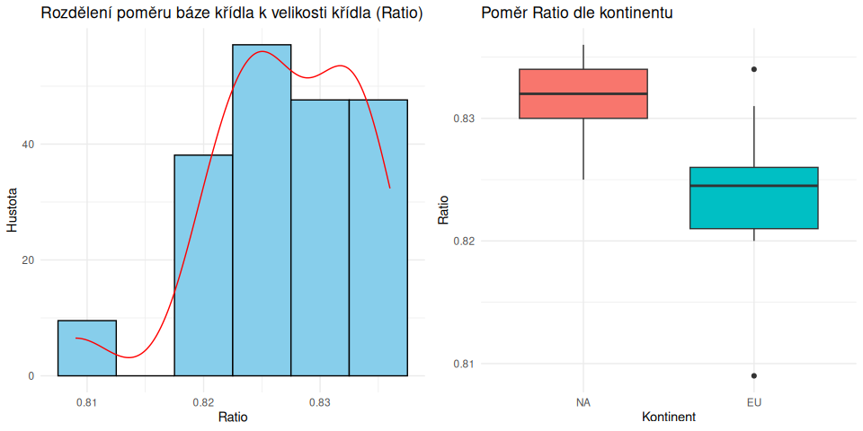

```r
plot_ratio_hist <- ggplot(data, aes(x = Ratio)) +
  geom_histogram(aes(y = ..density..), binwidth = 0.005, fill = "skyblue", color = "black") +
  geom_density(color = "red") +
  labs(title = "Rozdělení poměru báze křídla k velikosti křídla (Ratio)", x = "Ratio", y = "Hustota") +
  theme_minimal()

plot_ratio_continent_boxplot <- ggplot(data, aes(x = Continent, y = Ratio, fill = Continent)) +
  geom_boxplot(show.legend = FALSE) +
  labs(title = "Poměr Ratio dle kontinentu", x = "Kontinent", y = "Ratio") +
  theme_minimal()

cowplot::plot_grid(plot_ratio_hist, plot_ratio_continent_boxplot, ncol = 2)
```

Histogram Ratio naznačuje poměrně rovnoměrné rozdělení od 0.82 do 0.84. Box plot ukazuje, že lokality v Severní Americe (NA) mají tendenci větší průměrné Ratio než lokality v Evropě (EU), s menším rozptylem hodnot.

Prozkoumáme vztahy mezi Ratio a numerickými prediktory (Latitude, Females, Males) pomocí bodových grafů, s rozlišením dle kontinentu.

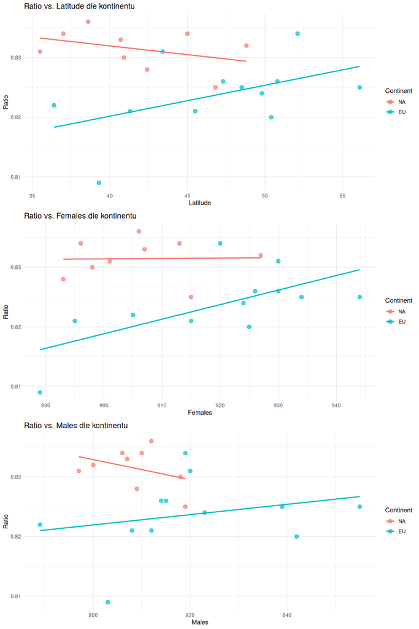

```r
plot_ratio_lat <- ggplot(data, aes(x = Latitude, y = Ratio, color = Continent)) +
  geom_point(alpha = 0.7, size = 3) +
  geom_smooth(method = "lm", se = FALSE) +
  labs(title = "Ratio vs. Latitude dle kontinentu") +
  theme_minimal()

plot_ratio_fem <- ggplot(data, aes(x = Females, y = Ratio, color = Continent)) +
  geom_point(alpha = 0.7, size = 3) +
  geom_smooth(method = "lm", se = FALSE) +
  labs(title = "Ratio vs. Females dle kontinentu") +
  theme_minimal()

plot_ratio_mal <- ggplot(data, aes(x = Males, y = Ratio, color = Continent)) +
  geom_point(alpha = 0.7, size = 3) +
  geom_smooth(method = "lm", se = FALSE) +
  labs(title = "Ratio vs. Males dle kontinentu") +
  theme_minimal()

cowplot::plot_grid(plot_ratio_lat, plot_ratio_fem, plot_ratio_mal, nrow = 3)
```

Z grafů plyne:

- Ratio má k Latitude slabý kladný vztah v Evropě a slabý záporný vztah v Severní Americe.
- Ratio má kladný vztah k Females (velikosti křídel) v Evropě a neutrální/zanedbatelný vztah v Severní Americe. Čím větší křídla, tím větší Ratio.
- Ratio má slabý kladný vztah k Males (velikosti křídel) v Evropě a slabý záporný vztah v Severní Americe. Čím větší křídla, tím v Evropě větší Ratio a tím v Severní Americe menší Ratio.

## Lineární regrese s numerickým regresorem

Vybereme proměnnou `Females` jako numerický regresor pro vysvětlení variability v proměnné Ratio, protože se na základě grafu zdá, že má s vysvětlovanou proměnou `Ratio` nejsilnější lineární vztah.

### Odhad modelu a interpretace

Nafitujeme lineární a kvadratický model lineární regrese s regresorem `Female` a regresandem `Ratio`.

```r
fit_lin <- lm(Ratio ~ Females, data=data)
fit_quad <- lm(Ratio ~ Females + I(Females^2), data=data)
data_lin <- cbind(data, predict(fit_lin, interval = "prediction"))
data_quad <- cbind(data, predict(fit_quad, interval = "prediction"))
```

Prohlédneme si statistické shrnutí a ANOVA tabulku pro nafitované modely.

```r
summary(fit_lin)
```

```
Call:
lm(formula = Ratio ~ Females, data = data)

Residuals:
      Min        1Q    Median        3Q       Max
-0.017113 -0.003357 -0.001428  0.004536  0.009283

Coefficients:
             Estimate Std. Error t value Pr(>|t|)
(Intercept) 7.945e-01  8.698e-02   9.135 2.21e-08 ***
Females     3.554e-05  9.515e-05   0.374    0.713
---
Signif. codes:  0 ‘***’ 0.001 ‘**’ 0.01 ‘*’ 0.05 ‘.’ 0.1 ‘ ’ 1

Residual standard error: 0.006561 on 19 degrees of freedom
Multiple R-squared:  0.00729,   Adjusted R-squared:  -0.04496
F-statistic: 0.1395 on 1 and 19 DF,  p-value: 0.7129
```

```r
anova(fit_lin)
```

```
Analysis of Variance Table

Response: Ratio
          Df     Sum Sq    Mean Sq F value Pr(>F)
Females    1 0.00000601 6.0070e-06  0.1395 0.7129
Residuals 19 0.00081799 4.3052e-05
```

### Evaluace

**Residua:** Predikce lineárního model se od skutečné hodnoty odchylovala nejhůře o -0.0171 a 0.0093. V prostředních 50% se odchylovala nejhůře o -0.0033 a 0.0045. Mediánem odchylky byla hodnota -0.0014.

**Koeficienty:** Odhad koeficientu pro průsečík je přibližně 0.79. Odhad koeficientu pro Females je přibližně 0.000036. Hodnota koeficientu je velmi nízká, takový model se pravděpodobně nebude přiliš odchylovat od modelu predikujícího průměrem.

**Koeficient Determinace R²:** S koeficientem 0.00729 je lineární model jen o velmi málo lepší než model, který vždy predikuje průměrnou hodnotou. Délká křídel samičky vysvětluje jen malou část variability v proměnné `Ratio`.

### Hypotéza

H0: Skutečný koeficient u Females je nulový.

HA: Skutečný koeficient u Females není nulový.

**Závěr:** Na základě výsledku F-testu s p-hodnotou 0.71 na hladině významnosti 5% nezamítáme nulovou hypotézu o nulovosti všech koeficientů. Přidání regeresoru `Females` nezlepšuje statisticky významně kvalitu modelu.

```r
summary(fit_quad)
```

```
Call:
lm(formula = Ratio ~ Females + I(Females^2), data = data)

Residuals:
      Min        1Q    Median        3Q       Max
-0.012584 -0.004468  0.003586  0.004258  0.008865

Coefficients:
               Estimate Std. Error t value Pr(>|t|)
(Intercept)  -8.180e+00  5.155e+00  -1.587   0.1300
Females       1.967e-02  1.128e-02   1.744   0.0982 .
I(Females^2) -1.073e-05  6.166e-06  -1.741   0.0987 .
---
Signif. codes:  0 ‘***’ 0.001 ‘**’ 0.01 ‘*’ 0.05 ‘.’ 0.1 ‘ ’ 1

Residual standard error: 0.006237 on 18 degrees of freedom
Multiple R-squared:  0.1504,    Adjusted R-squared:  0.05597
F-statistic: 1.593 on 2 and 18 DF,  p-value: 0.2307
```

```r
anova(fit_quad)
```

```
Analysis of Variance Table

Response: Ratio
             Df     Sum Sq    Mean Sq F value  Pr(>F)
Females       1 0.00000601 6.0070e-06  0.1544 0.69895
I(Females^2)  1 0.00011790 1.1790e-04  3.0314 0.09873 .
Residuals    18 0.00070009 3.8894e-05
---
Signif. codes:  0 ‘***’ 0.001 ‘**’ 0.01 ‘*’ 0.05 ‘.’ 0.1 ‘ ’ 1
```

### Evaluace

**Residua:** Predikce kvadratického model se od skutečné hodnoty odchylovala nejhůře o -0.0125 a 0.0089. V prostředních 50% se odchylovala nejhůře o -0.0045 a 0.0042. Mediánem odchylky byla hodnota 0.0036. Celkově se residua kvadratického modelu velmi podobají residuím lineárního modelu.

**Koeficienty:** Odhad koeficientu pro průsečík je přibližně -8.18. Odhad koeficientu pro Females je přibližně 0.02 a odhad koeficientu pro I*(Females^2) je −0.00001. Koeficienty jsou i v tomto případě velmi malé.

**ANOVA:** Přidání samotného regresoru `Females` vedlo k p-hodnotě 0.7. Následné přidání kvadratického členu vedlo k p-hodnotě 0.09. Na standardní hladině významnosti 5% se stále jedná o statisticky nevýznamné zlepšení. Jedná se však o výrazně nižší hodnotu než u samotného lineárního členu.

### Hypotéza

H0: Všechny skutečné koeficienty (kromě průsečíku) jsou nulové.

HA: Nějaký skutečný koeficient (kromě průsečíku) je nenulový.

**Závěr:** Na základě výsledku F-testu s p-hodnotou 0.23 na hladině významnosti 5% nezamítáme nulovou hypotézu o nulovosti všech koeficientů. Přidání regeresoru `Females` a jeho kvadratické verze nezlepšuje statisticky významně kvalitu modelu. Nicméně je nutno podotknout, že p-hodnota kvadratického modelu je významně nižší než p-hodnota modelu lineárního.

### Graf regresní závislosti

Vizualizujeme vztah mezi vysvětlovanou proměnnou `Ratio` a vysvětlující proměnnou `Females`.

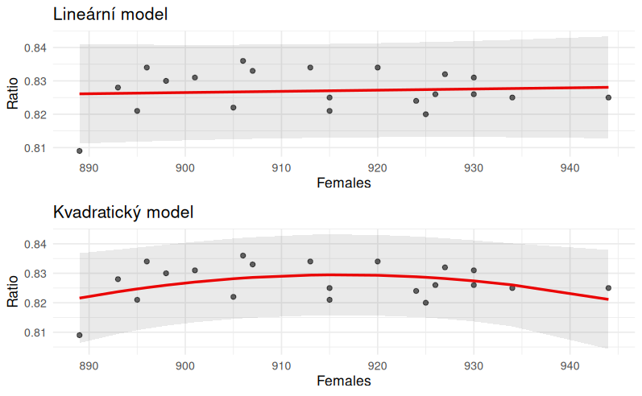

```r
p1 <- ggplot() +
  geom_point(data = data_lin, aes(x = Females, y = Ratio), alpha = 0.6) +
  geom_line(data = data_lin, aes(x = Females, y = fit), size = 1, color = "red") +
  geom_ribbon(data = data_lin, aes(x = Females, ymin = lwr, ymax = upr), alpha = 0.1) +
  labs(title = "Lineární model") +
  theme_minimal()
p2 <- ggplot() +
  geom_point(data = data_quad, aes(x = Females, y = Ratio), alpha = 0.6) +
  geom_line(data = data_quad, aes(x = Females, y = fit), size = 1, color = "red") +
  geom_ribbon(data = data_quad, aes(x = Females, ymin = lwr, ymax = upr), alpha = 0.1) +
  labs(title = "Kvadratický model") +
  theme_minimal()

cowplot::plot_grid(p1, p2, nrow=2)
```

Vzhledem k výsledkům z předchozích testů je tvar křivek nepřekvapivý. Přímka lineárního modelu je téměř vodorovná. Hodnota `Ratio` na `Females` samotných pravděpodobně téměř vůbec nezávisí. Zdá se, že informace o původu `Continent` byla pro vysvětlení závislosti klíčová.

## Analýza rozptylu s kategoriální regresorem

Vybereme proměnnou `Continent` jako kategoriální regresor pro vysvětlení variability v proměnné `Ratio`.

### Odhad modelu a interpretace

Nafitujeme model lineární regrese s kategorickým regresorem. R automaticky vytvoří dummy proměnnou a vybere jednu úroveň faktoru jako referenční úroveň.

```r
fit_cat <- lm(Ratio ~ Continent, data = data)
data_cat <- cbind(data, predict(fit_cat, interval = "prediction"))
```

Prohlédneme si statistické shrnutí a ANOVA tabulku pro nafitovaný model.

```r
summary(fit_cat)
```

```
Call:
lm(formula = Ratio ~ Continent, data = data)

Residuals:
       Min         1Q     Median         3Q        Max
-0.0146667 -0.0026667  0.0005556  0.0023333  0.0103333

Coefficients:
             Estimate Std. Error t value Pr(>|t|)
(Intercept)  0.831444   0.001732 480.087  < 2e-16 ***
ContinentEU -0.007778   0.002291  -3.395  0.00304 **
---
Signif. codes:  0 ‘***’ 0.001 ‘**’ 0.01 ‘*’ 0.05 ‘.’ 0.1 ‘ ’ 1

Residual standard error: 0.005196 on 19 degrees of freedom
Multiple R-squared:  0.3776,    Adjusted R-squared:  0.3448
F-statistic: 11.53 on 1 and 19 DF,  p-value: 0.00304
```

```r
anova(fit_cat)
```

```
Analysis of Variance Table

Response: Ratio
          Df     Sum Sq    Mean Sq F value  Pr(>F)
Continent  1 0.00031111 3.1111e-04  11.525 0.00304 **
Residuals 19 0.00051289 2.6994e-05
---
Signif. codes:  0 ‘***’ 0.001 ‘**’ 0.01 ‘*’ 0.05 ‘.’ 0.1 ‘ ’ 1
```

### Evaluace

**Residua:** Predikce kategorického modelu se od skutečné hodnoty odchylovala nejhůře o -0.0145 a 0.0103. V prostředních 50% se odchylovala nejhůře o -0.0027 a 0.0023. Mediánem odchylky byla hodnota 0.0006. V prostředních 50% i v mediánu jsou residua významně menší než u numerického regresoru.

**Koeficienty:** Odhad koeficientu pro průsečík je přibližně 0.83144. Odhad koeficientu pro ContinentEU je přibližně -0.0078. Tedy je-li hodnota `Continent` NA (Severní Amerika) pak predikuje model hodnotu 0.83144. V případě hodnoty `Continent` EU (Evropa) predikuje základem sníženým o 0.0078, tedy hodnotou 0,823666.

**Koeficient Determinace R²:** S koeficientem 0.3776 je kategorický model zatím vysvětluje největší podíl variability. Adjustovaná hodnota 0.3448 je také dosud nejvyšší.

### Hypotéza

H0: Střední hodnota Ratio je stejná na obou kontinentech (NA a EU).

HA: Střední hodnota Ratio se liší mezi kontinenty.

**Závěr:** Na základě p-hodnoty 0.003 na hladině významnosti 5% **zamítáme** nulovou hypotézu ve prospěch alternativy, že střední hodnoty se mezi kontinenty **liší**. Na rozdíl od numerického regresoru pozorujeme statisticky významnou závislost na kategorickém regresoru `Continent`.

```r
data_na <- data[data$Continent == "NA",]
data_eu <- data[data$Continent == "EU",]
mean_na <- mean(data_na$Ratio)
mean_eu <- mean(data_eu$Ratio)
cat("Průměr proměnné Ratio je", mean_na, "v Severní Americe a", mean_eu, "v Evropě.")
```

```
Průměr proměnné Ratio je 0.8314444 v Severní Americe a 0.8236667 v Evropě.
```

Z vypsaného průměru na jednotlivých kontinentech vidíme, že fitnuté koeficienty skutečně odpovídají.

Rozdělení hodnoty `Ratio` napříč kontinenty včetně průměrů je vidět i na grafu.

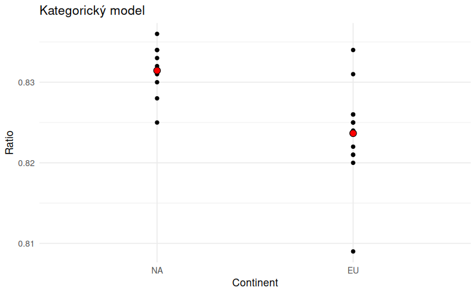

```r
ggplot(data_cat, aes(x = Continent, y = Ratio)) +
    geom_point() +
    stat_summary(
        geom = "point",
        fun.y = "mean",
        size = 3,
        shape = 21,
        fill = "red"
    ) +
    labs(title = "Kategorický model") +
    theme_minimal()
```

## Regresní model s numerickým, kategoriálním regresorem a interakcí

Nyní uvažujeme model, který zahrnuje Females, Continent, a navíc i jejich interakci.

### Odhad modelu a interpretace

Použijeme syntaxi regresor1 * regresor2 k zahrnutí hlavních efektů i interakce.

```r
fit_int <- lm(Ratio ~ Continent * Females, data = data)
fit_int_reverse <- lm(Ratio ~ Females * Continent, data = data)
data_int <- cbind(data, predict(fit_int, interval="prediction"))
```

Prohlédneme si nejdříve statistické shrnutí nafitovaného modelu.

```r
summary(fit_int)
```

```
Call:
lm(formula = Ratio ~ Continent * Females, data = data)

Residuals:
       Min         1Q     Median         3Q        Max
-0.0071611 -0.0021449 -0.0001685  0.0025110  0.0102723

Coefficients:
                      Estimate Std. Error t value Pr(>|t|)
(Intercept)          8.255e-01  1.331e-01   6.200 9.69e-06 ***
ContinentEU         -2.263e-01  1.537e-01  -1.473    0.159
Females              6.574e-06  1.469e-04   0.045    0.965
ContinentEU:Females  2.375e-04  1.689e-04   1.406    0.178
---
Signif. codes:  0 ‘***’ 0.001 ‘**’ 0.01 ‘*’ 0.05 ‘.’ 0.1 ‘ ’ 1

Residual standard error: 0.004479 on 17 degrees of freedom
Multiple R-squared:  0.5861,    Adjusted R-squared:  0.5131
F-statistic: 8.026 on 3 and 17 DF,  p-value: 0.001507
```

### Evaluace

**Koeficienty:** Odhad koeficientu pro průsečík je přibližně 0.8255. Odhad koeficientu pro ContinentEU je přibližně -0.2263. Odhad koeficientu pro Females je přibližně 0.000007. Interakční koeficient (změna směrnice Females v případě ContinentEU) Females:ContinentEU je odhadnut na 0.0002.

**Koeficient Determinace R²:** S koeficientem 0.5861 se jedná o dosud nejlepší model. Adjustovaná hodnota 0.5131 je také nejvyšší.

### Hypotézy

H0: Všechny skutečné koeficienty (kromě průsečíku) jsou nulové.

HA: Nějaký skutečný koeficient (kromě průsečíku) je nenulový.

**Závěr:** Na základě výsledku F-testu s p-hodnotou 0.0015 na hladině významnosti 5% zamítáme nulovou hypotézu ve prospěch alternativy, že nějaký skutečný koeficient (kromě průsečíku) je nenulový. Pozorujeme tedy statisticky významnou závislost na regresorech.

H0: Konkrétní skutečný koeficient je nulový.

HA: Konkrétní skutečný koeficient není nulový.

**Závěr:** Na základě výsledků t-testu s p-hodnotami 0.159, 0.965 a 0.178 na hladině významnosti 5% nezamítáme žádnou nulovou hypotézu o nulovosti konkrétního koeficientu. Ačkoliv je celková nenulovost statisticky významná, nedokážeme prokázat nenulovost žádného konkrétního koeficientu.

Prohlédneme si ANOVA tabulky v obou pořadích.

```r
anova(fit_int)
```

```
Analysis of Variance Table

Response: Ratio
                  Df     Sum Sq    Mean Sq F value  Pr(>F)
Continent          1 0.00031111 3.1111e-04 15.5093 0.00106 **
Females            1 0.00013222 1.3222e-04  6.5913 0.01998 *
Continent:Females  1 0.00003966 3.9656e-05  1.9769 0.17773
Residuals         17 0.00034101 2.0060e-05
---
Signif. codes:  0 ‘***’ 0.001 ‘**’ 0.01 ‘*’ 0.05 ‘.’ 0.1 ‘ ’ 1
```

```r
anova(fit_int_reverse)
```

```
Analysis of Variance Table

Response: Ratio
                  Df     Sum Sq    Mean Sq F value    Pr(>F)
Females            1 0.00000601 0.00000601  0.2994 0.5913478
Continent          1 0.00043732 0.00043732 21.8012 0.0002202 ***
Females:Continent  1 0.00003966 0.00003966  1.9769 0.1777292
Residuals         17 0.00034101 0.00002006
---
Signif. codes:  0 ‘***’ 0.001 ‘**’ 0.01 ‘*’ 0.05 ‘.’ 0.1 ‘ ’ 1
```

**ANOVA:** Přidání regresoru `Continent` vedlo ve všech případech ke statisticky významnému zlepšení. Přidání regresoru `Females` bylo významné pouze pokud model již obsahoval regresor `Continent`. Přidání interakčního členu nevedlo ke statisticky významnému zlepšení.

**Interakční člen**: Ačkoliv se z dat a ze zvolených koeficientů modelu zdá, že efekt regresoru `Females` je výrazně odlišný v Severní Americe a v Evropě, neexistuje statisticky významný důkaz. Na velmi omezeném datovém vzorku takový jev mohl vzniknout i pohou náhodou.

### Graf regresní závislosti s interakcí

Graficky zobrazíme regresní přímky pro každý kontinent, abychom viděli, jak se sklon liší.

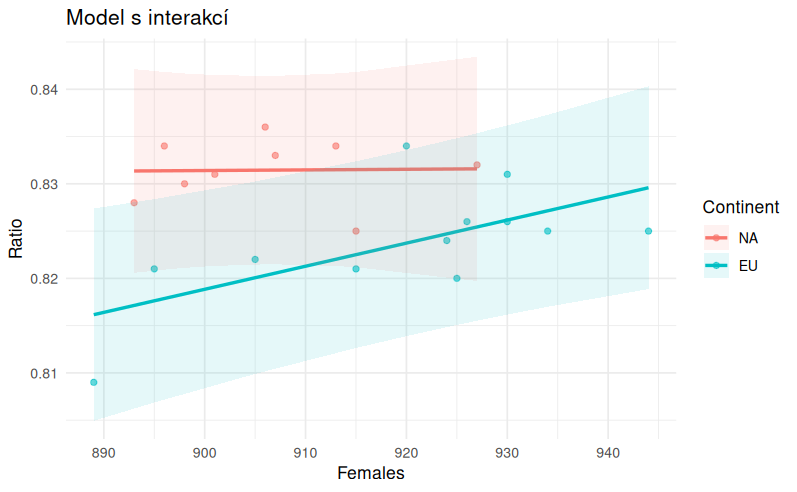

```r
ggplot() +
    geom_point(data = data_int, aes(x = Females, y = Ratio, color = Continent), alpha = 0.6) +
    geom_line(data = data_int, aes(x = Females, y = fit, color = Continent), size = 1) +
    geom_ribbon(data = data_int, aes(x = Females, ymin = lwr, ymax = upr, fill = Continent), alpha = 0.1) +
    labs(title = "Model s interakcí") +
    theme_minimal()
```

## Model s více regresory a výběr finálního modelu

### Významnost Regresorů

Nejdříve vyzkoušíme statistickou významnost samotných regresorů.

```r
anova(lm(Ratio ~ Latitude, data = data))
```

```
Analysis of Variance Table

Response: Ratio
          Df     Sum Sq    Mean Sq F value Pr(>F)
Latitude   1 0.00000522 5.2170e-06  0.1211 0.7317
Residuals 19 0.00081878 4.3094e-05
```

```r
anova(lm(Ratio ~ Males, data = data))
```

```
Analysis of Variance Table

Response: Ratio
          Df     Sum Sq    Mean Sq F value Pr(>F)
Males      1 0.00000952 9.5170e-06   0.222 0.6429
Residuals 19 0.00081448 4.2868e-05
```

```r
anova(lm(Ratio ~ SE.M, data = data))
```

```
Analysis of Variance Table

Response: Ratio
          Df    Sum Sq    Mean Sq F value Pr(>F)
SE.M       1 0.0000133 1.3303e-05  0.3118 0.5831
Residuals 19 0.0008107 4.2668e-05
```

```r
anova(lm(Ratio ~ Females, data = data))
```

```
Analysis of Variance Table

Response: Ratio
          Df     Sum Sq    Mean Sq F value Pr(>F)
Females    1 0.00000601 6.0070e-06  0.1395 0.7129
Residuals 19 0.00081799 4.3052e-05
```

```r
anova(lm(Ratio ~ SE.F, data = data))
```

```
Analysis of Variance Table

Response: Ratio
          Df    Sum Sq   Mean Sq F value  Pr(>F)
SE.F       1 0.0001193 1.193e-04  3.2165 0.08883 .
Residuals 19 0.0007047 3.709e-05
---
Signif. codes:  0 ‘***’ 0.001 ‘**’ 0.01 ‘*’ 0.05 ‘.’ 0.1 ‘ ’ 1
```

```r
anova(lm(Ratio ~ Continent, data = data))
```

```
Analysis of Variance Table

Response: Ratio
          Df     Sum Sq    Mean Sq F value  Pr(>F)
Continent  1 0.00031111 3.1111e-04  11.525 0.00304 **
Residuals 19 0.00051289 2.6994e-05
---
Signif. codes:  0 ‘***’ 0.001 ‘**’ 0.01 ‘*’ 0.05 ‘.’ 0.1 ‘ ’ 1
```

Takto je jediným statisticky významný regresorem proměnná `Continent`. Ten zjevně bude součástí každého úspěšného modelu, vyzkoušíme tedy významnost dalších regresorů společně s ním.

```r
anova(lm(Ratio ~ Continent + Latitude, data = data))
```

```
Analysis of Variance Table

Response: Ratio
          Df     Sum Sq    Mean Sq F value   Pr(>F)
Continent  1 0.00031111 3.1111e-04 11.8003 0.002952 **
Latitude   1 0.00003832 3.8323e-05  1.4536 0.243564
Residuals 18 0.00047457 2.6365e-05
---
Signif. codes:  0 ‘***’ 0.001 ‘**’ 0.01 ‘*’ 0.05 ‘.’ 0.1 ‘ ’ 1
```

```r
anova(lm(Ratio ~ Continent + Males, data = data))
```

```
Analysis of Variance Table

Response: Ratio
          Df     Sum Sq    Mean Sq F value   Pr(>F)
Continent  1 0.00031111 3.1111e-04  11.229 0.003557 **
Males      1 0.00001418 1.4185e-05   0.512 0.483462
Residuals 18 0.00049870 2.7706e-05
---
Signif. codes:  0 ‘***’ 0.001 ‘**’ 0.01 ‘*’ 0.05 ‘.’ 0.1 ‘ ’ 1
```

```r
anova(lm(Ratio ~ Continent + SE.M, data = data))
```

```
Analysis of Variance Table

Response: Ratio
          Df     Sum Sq    Mean Sq F value   Pr(>F)
Continent  1 0.00031111 3.1111e-04 10.9242 0.003936 **
SE.M       1 0.00000027 2.6800e-07  0.0094 0.923850
Residuals 18 0.00051262 2.8479e-05
---
Signif. codes:  0 ‘***’ 0.001 ‘**’ 0.01 ‘*’ 0.05 ‘.’ 0.1 ‘ ’ 1
```

```r
anova(lm(Ratio ~ Continent + Females, data = data))
```

```
Analysis of Variance Table

Response: Ratio
          Df     Sum Sq    Mean Sq F value   Pr(>F)
Continent  1 0.00031111 3.1111e-04  14.711 0.001212 **
Females    1 0.00013222 1.3222e-04   6.252 0.022290 *
Residuals 18 0.00038067 2.1148e-05
---
Signif. codes:  0 ‘***’ 0.001 ‘**’ 0.01 ‘*’ 0.05 ‘.’ 0.1 ‘ ’ 1
```

```r
anova(lm(Ratio ~ Continent + SE.F, data = data))
```

```
Analysis of Variance Table

Response: Ratio
          Df     Sum Sq    Mean Sq F value   Pr(>F)
Continent  1 0.00031111 3.1111e-04 11.5765 0.003174 **
SE.F       1 0.00002915 2.9151e-05  1.0847 0.311436
Residuals 18 0.00048374 2.6874e-05
---
Signif. codes:  0 ‘***’ 0.001 ‘**’ 0.01 ‘*’ 0.05 ‘.’ 0.1 ‘ ’ 1
```

Jako jediný další významný regresor se prokázala proměnná `Females`. Zkusíme stejný postupem najít další významný regresor.

```r
anova(lm(Ratio ~ Continent + Females + Latitude, data = data))
```

```
Analysis of Variance Table

Response: Ratio
          Df     Sum Sq    Mean Sq F value   Pr(>F)
Continent  1 0.00031111 3.1111e-04 14.0555 0.001598 **
Females    1 0.00013222 1.3222e-04  5.9734 0.025722 *
Latitude   1 0.00000438 4.3830e-06  0.1980 0.661942
Residuals 17 0.00037629 2.2135e-05
---
Signif. codes:  0 ‘***’ 0.001 ‘**’ 0.01 ‘*’ 0.05 ‘.’ 0.1 ‘ ’ 1
```

```r
anova(lm(Ratio ~ Continent + Females + Males, data = data))
```

```
Analysis of Variance Table

Response: Ratio
          Df     Sum Sq    Mean Sq F value  Pr(>F)
Continent  1 0.00031111 3.1111e-04 14.5411 0.00139 **
Females    1 0.00013222 1.3222e-04  6.1798 0.02362 *
Males      1 0.00001695 1.6951e-05  0.7923 0.38584
Residuals 17 0.00036372 2.1395e-05
---
Signif. codes:  0 ‘***’ 0.001 ‘**’ 0.01 ‘*’ 0.05 ‘.’ 0.1 ‘ ’ 1
```

```r
anova(lm(Ratio ~ Continent + Females + SE.M, data = data))
```

```
Analysis of Variance Table

Response: Ratio
          Df     Sum Sq    Mean Sq F value   Pr(>F)
Continent  1 0.00031111 3.1111e-04 14.1110 0.001573 **
Females    1 0.00013222 1.3222e-04  5.9970 0.025471 *
SE.M       1 0.00000586 5.8630e-06  0.2659 0.612719
Residuals 17 0.00037481 2.2047e-05
---
Signif. codes:  0 ‘***’ 0.001 ‘**’ 0.01 ‘*’ 0.05 ‘.’ 0.1 ‘ ’ 1
```

```r
anova(lm(Ratio ~ Continent + Females + SE.F, data = data))
```

```
Analysis of Variance Table

Response: Ratio
          Df     Sum Sq    Mean Sq F value   Pr(>F)
Continent  1 0.00031111 3.1111e-04 14.0503 0.001601 **
Females    1 0.00013222 1.3222e-04  5.9712 0.025746 *
SE.F       1 0.00000424 4.2440e-06  0.1917 0.667057
Residuals 17 0.00037643 2.2143e-05
---
Signif. codes:  0 ‘***’ 0.001 ‘**’ 0.01 ‘*’ 0.05 ‘.’ 0.1 ‘ ’ 1
```

Žádný další významný regresor již nebyl nalezen. Dále můžeme sestrojit model obsahující všechny potenciální regresory a analyzovat jejich významnost pomocí t-testů.

```r
summary(lm(Ratio ~ Continent + Females + Males + SE.F + SE.M + Latitude, data = data))
```

```
Call:
lm(formula = Ratio ~ Continent + Females + Males + SE.F + SE.M +
    Latitude, data = data)

Residuals:
       Min         1Q     Median         3Q        Max
-0.0085836 -0.0018945  0.0005699  0.0021510  0.0092245

Coefficients:
              Estimate Std. Error t value Pr(>|t|)
(Intercept)  6.809e-01  1.018e-01   6.689 1.03e-05 ***
ContinentEU -9.396e-03  2.685e-03  -3.499  0.00354 **
Females      3.049e-04  1.347e-04   2.263  0.04008 *
Males       -1.459e-04  1.226e-04  -1.190  0.25385
SE.F        -1.387e-04  1.270e-03  -0.109  0.91464
SE.M        -1.498e-03  1.346e-03  -1.114  0.28423
Latitude    -4.962e-05  3.038e-04  -0.163  0.87259
---
Signif. codes:  0 ‘***’ 0.001 ‘**’ 0.01 ‘*’ 0.05 ‘.’ 0.1 ‘ ’ 1

Residual standard error: 0.004868 on 14 degrees of freedom
Multiple R-squared:  0.5974,    Adjusted R-squared:  0.4248
F-statistic: 3.462 on 6 and 14 DF,  p-value: 0.02603
```

I tento přístup označil jako významné pouze regresory `Content` a `Females`.

### Postup

Prvním krokem pro nalezení vhodného modelu bude nalezení nejlepšího modelu podle informačních kritérií.

K nejlepšímu modelu budeme postupně hledat podmodely, které jeho kvalitu významně nezhorší.

Jako vhodný model prohlásíme ten nejlepší z nich, který je zároveň statisticky významně lepší než jeho podmodely a neobsahuje žádné nevýznamné regresory.

### Volba modelu

K nalezení nejšikovnějšího modelu použijeme sekvenční přístup a funkci `step`.

```r
step(
    lm(Ratio~1,data=data),
    scope = list(lower=~1,upper=~Continent * Males * Females * Latitude * SE.F * SE.M),
    data = data
)
```

```
Start:  AIC=-211.06
Ratio ~ 1

            Df  Sum of Sq        RSS     AIC
+ Continent  1 3.1111e-04 0.00051289 -219.02
+ SE.F       1 1.1930e-04 0.00070470 -212.35
<none>                    0.00082400 -211.06
+ SE.M       1 1.3303e-05 0.00081070 -209.41
+ Males      1 9.5170e-06 0.00081448 -209.31
+ Females    1 6.0070e-06 0.00081799 -209.22
+ Latitude   1 5.2170e-06 0.00081878 -209.20

Step:  AIC=-219.02
Ratio ~ Continent

            Df  Sum of Sq        RSS     AIC
+ Females    1 1.3222e-04 0.00038067 -223.28
<none>                    0.00051289 -219.02
+ Latitude   1 3.8323e-05 0.00047457 -218.65
+ SE.F       1 2.9151e-05 0.00048374 -218.25
+ Males      1 1.4185e-05 0.00049870 -217.61
+ SE.M       1 2.6800e-07 0.00051262 -217.03
- Continent  1 3.1111e-04 0.00082400 -211.06

Step:  AIC=-223.28
Ratio ~ Continent + Females

                    Df  Sum of Sq        RSS     AIC
+ Continent:Females  1 0.00003966 0.00034101 -223.59
<none>                            0.00038067 -223.28
+ Males              1 0.00001695 0.00036372 -222.24
+ SE.M               1 0.00000586 0.00037481 -221.61
+ Latitude           1 0.00000438 0.00037629 -221.52
+ SE.F               1 0.00000424 0.00037643 -221.52
- Females            1 0.00013222 0.00051289 -219.02
- Continent          1 0.00043732 0.00081799 -209.22

Step:  AIC=-223.59
Ratio ~ Continent + Females + Continent:Females

```

[output cut: 29 more lines]

```
+ Females:SE.M       1 5.7890e-06 0.00023896 -225.06
+ Males:SE.M         1 3.1140e-06 0.00024164 -224.82
+ Continent:Males    1 2.3300e-07 0.00024452 -224.58
+ SE.F               1 1.7100e-07 0.00024458 -224.57
+ Continent:SE.M     1 6.8000e-08 0.00024468 -224.56
- Continent:Females  1 8.7982e-05 0.00033273 -222.11
- Males              1 9.5939e-05 0.00034069 -221.61

Call:
lm(formula = Ratio ~ Continent + Females + Males + SE.M + Continent:Females,
    data = data)

Coefficients:
        (Intercept)          ContinentEU              Females                Males                 SE.M  ContinentEU:Females
          9.932e-01           -3.798e-01            5.519e-05           -2.557e-04           -1.421e-03            4.074e-04
```

Na základě předchozích výsledků nafitujeme zajímavé modely a zobrazíme informační kritéria.

```r
fit_intercept <- lm(Ratio ~ 1, data = data)
fit_continent <- lm(Ratio ~ Continent, data = data)
fit_add <- lm(Ratio ~ Continent + Females, data = data)
fit_int <- lm(Ratio ~ Continent + Females + Continent:Females, data = data)
fit_with_males <- lm(Ratio ~ Continent + Females + Males + Continent:Females, data = data)
fit_complex <- lm(formula = Ratio ~ Continent + Females + Males + SE.M + Continent:Females,
    data = data)

models <- list(fit_intercept, fit_continent, fit_add, fit_int, fit_with_males, fit_complex)
cbind(
    AIC(fit_intercept, fit_continent, fit_add, fit_int, fit_with_males, fit_complex),
    BIC(fit_intercept, fit_continent, fit_add, fit_int, fit_with_males, fit_complex)
)
```

|  | df | AIC | df | BIC |
| --- | --- | --- | --- | --- |
| fit_intercept | 2 | -149.4677 | 2 | -147.3786 |
| fit_continent | 3 | -157.4240 | 3 | -154.2905 |
| fit_add | 4 | -161.6847 | 4 | -157.5066 |
| fit_int | 5 | -161.9949 | 5 | -156.7723 |
| fit_with_males | 6 | -164.7625 | 6 | -158.4954 |
| fit_complex | 7 | -164.9603 | 7 | -157.6486 |

Dále budeme postupně aplikovat testy **model vs. podmodel** dokud nenalezneme nejlepší model, který je statisticky významně lepší než ten jednodušší.

```r
anova(fit_intercept, fit_continent, fit_add, fit_int, fit_with_males, fit_complex)
```

```
Analysis of Variance Table

Model 1: Ratio ~ 1
Model 2: Ratio ~ Continent
Model 3: Ratio ~ Continent + Females
Model 4: Ratio ~ Continent + Females + Continent:Females
Model 5: Ratio ~ Continent + Females + Males + Continent:Females
Model 6: Ratio ~ Continent + Females + Males + SE.M + Continent:Females
  Res.Df        RSS Df  Sum of Sq       F    Pr(>F)
1     20 0.00082400
2     19 0.00051289  1 3.1111e-04 19.0671 0.0005527 ***
3     18 0.00038067  1 1.3222e-04  8.1033 0.0122496 *
4     17 0.00034101  1 3.9656e-05  2.4304 0.1398462
5     16 0.00027175  1 6.9260e-05  4.2448 0.0571588 .
6     15 0.00024475  1 2.7003e-05  1.6549 0.2177896
---
Signif. codes:  0 ‘***’ 0.001 ‘**’ 0.01 ‘*’ 0.05 ‘.’ 0.1 ‘ ’ 1
```

Nejlepší model, který je statisticky významně lepší než ten předchozí, je 3. model (Ratio ~ Continent + Females). Porovnáme jej ještě přímo s 5. nadějným modelem.

```r
anova(fit_add, fit_with_males)
```

```
Analysis of Variance Table

Model 1: Ratio ~ Continent + Females
Model 2: Ratio ~ Continent + Females + Males + Continent:Females
  Res.Df        RSS Df  Sum of Sq      F  Pr(>F)
1     18 0.00038067
2     16 0.00027175  2 0.00010892 3.2064 0.06745 .
---
Signif. codes:  0 ‘***’ 0.001 ‘**’ 0.01 ‘*’ 0.05 ‘.’ 0.1 ‘ ’ 1
```

Ani oproti 3. modelu není 5. model průkazně lepší. Prohlédneme tedy ještě ANOVA tabulku samotného 3. modelu.

```r
anova(fit_add)
```

```
Analysis of Variance Table

Response: Ratio
          Df     Sum Sq    Mean Sq F value   Pr(>F)
Continent  1 0.00031111 3.1111e-04  14.711 0.001212 **
Females    1 0.00013222 1.3222e-04   6.252 0.022290 *
Residuals 18 0.00038067 2.1148e-05
---
Signif. codes:  0 ‘***’ 0.001 ‘**’ 0.01 ‘*’ 0.05 ‘.’ 0.1 ‘ ’ 1
```

Přidáním regresoru `Continent` i `Females` je model statisticky významně vylepšen.

```r
summary(fit_add)
```

```
Call:
lm(formula = Ratio ~ Continent + Females, data = data)

Residuals:
       Min         1Q     Median         3Q        Max
-0.0089412 -0.0017822  0.0004248  0.0014107  0.0102868

Coefficients:
              Estimate Std. Error t value Pr(>|t|)
(Intercept)  6.627e-01  6.750e-02   9.818 1.18e-08 ***
ContinentEU -1.030e-02  2.264e-03  -4.547  0.00025 ***
Females      1.862e-04  7.447e-05   2.500  0.02229 *
---
Signif. codes:  0 ‘***’ 0.001 ‘**’ 0.01 ‘*’ 0.05 ‘.’ 0.1 ‘ ’ 1

Residual standard error: 0.004599 on 18 degrees of freedom
Multiple R-squared:  0.538, Adjusted R-squared:  0.4867
F-statistic: 10.48 on 2 and 18 DF,  p-value: 0.0009585
```

### Evaluace

**Residua:** Predikce kategorického modelu se od skutečné hodnoty odchylovala nejhůře o -0.0089 a 0.0103. V prostředních 50% se odchylovala nejhůře o -0.0018 a 0.0014. Mediánem odchylky byla hodnota 0.0004. Tyto hodnoty jen o málo horší než u modelu s interakcí.

**Koeficienty:** Odhad koeficientu pro průsečík je přibližně 0.6627 (oproti 0.8255 u `fit_int`). Odhad koeficientu pro ContinentEU je přibližně −0,0103 (oproti -0.2263 u `fit_int`). Odhad koeficientu pro Females je přibližně 0,0001862 (oproti 0.000007 u `fit_int`).

Model s interakcí měl oproti aditivnímu modelu velmi nízky koeficient u `Females`, kromě `Continent` se při predikci velmi opíral o interakční člen. Aditivní model neobsahuje interakční člen, proto je koeficient u `Females` výrazně vyšší. Jelikož se liší průměrná hodnota `Females` napříč regiony, vyšší koeficient u `Females` způsobil snížení koeficientu u `ContinentEU`. Vyšší koeficient u `Females` zároveň vedl ke snížení hodnoty průsečíku (intersect).

**Koeficient Determinace R²:** Koeficient 0.538 aditivního modelu je jen o 0.048 horší než u modelu s interakcí. Adjustovaná hodnota 0.4867 je o 0.026 horší než u modelu s interakcí.

### Hypotézy

**Závěr:** Na základě výsledků t-testu s p-hodnotami 0.00025 a 0.02229 na hladině významnosti 5% zamítáme všchny nulové hypotézy ve prospěch alternativ, že konkrétní koeficienty **nejsou** nulové a že regresory **jsou** pro model významné.

### Interpretace

Model se samotným kategorickým regresorem `Continent` sám vysvětluje až 37.76% variability. Model se samotným regresorem `Females` vysvětluje pouze 0.73% variability, pomáhá však dovysvětlit část zbylé variability a model s oběma regresory vysvětluje až 53.8%.

### Vizualizace

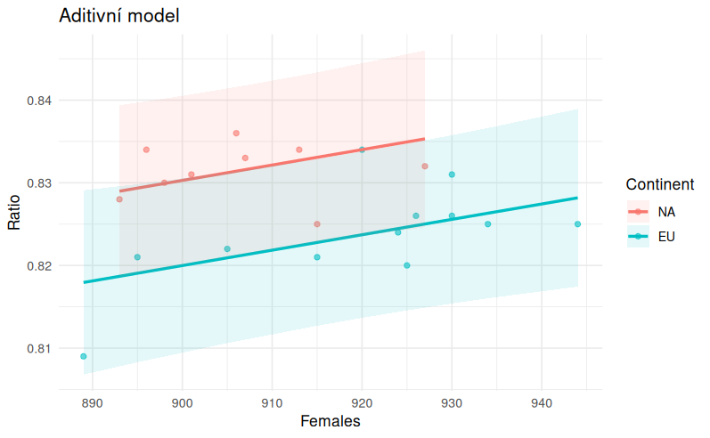

```r
data_add <- cbind(data, predict(fit_add, interval="prediction"))
ggplot() +
    geom_point(data = data_add, aes(x = Females, y = Ratio, color = Continent), alpha = 0.6) +
    geom_line(data = data_add, aes(x = Females, y = fit, color = Continent), size = 1) +
    geom_ribbon(data = data_add, aes(x = Females, ymin = lwr, ymax = upr, fill = Continent), alpha = 0.1) +
    labs(title = "Aditivní model") +
    theme_minimal()
```

## Ověření předpokladů použitých metod pro výběr finálního modelu

## Autokorelace reziduí

Model lineární regrese předpokládá, že chyba mezí odhadem a skutečnými hodnotami je náhodná. Předpokladem je tedy i nezávislost reziduí. S nezávislostí chyb počítájí použité t a F statistiky.

Sledujeme zda jsou rezidua vzájemně korelovaná. Z grafu žádná zjevná závislost neplyne.

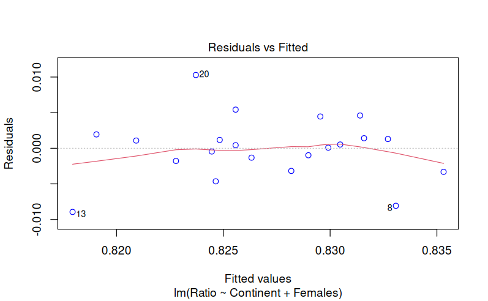

```r
plot(fit_add, which=1, col=c("blue"))
```

### Hypotéza

H0: Residua jsou vzájemně nezávislá.

HA: Residua nejsou vzájemně nezávislá (jsou autokorelovaná).

```r
ols_test_correlation(fit_add)
```

```
[1] 0.9767231
```

## Normalita reziduí

Ačkoliv normalita reziduí není předpokladem modelu lineární regrese, umožňuje nám dělat silnější tvrzení o jeho vlastnostech. Silné výchylky od normality mají negativní dopad na přesnost použitých t a F testů (obzvlášť u malých vzorků).

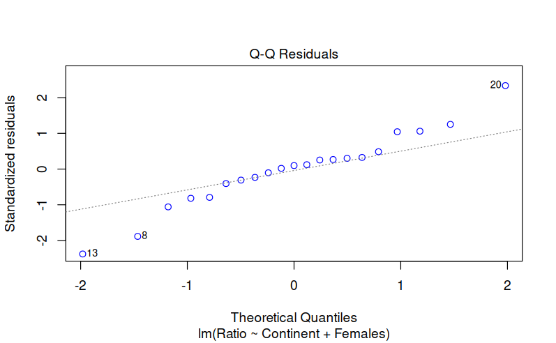

```r
plot(fit_add, which=2, col=c("blue"))
```

### Hypotéza

H0: Residua jsou normálně rozdělena.

HA: Residua nejsou normálně rozdělena.

```r
ols_test_normality(fit_add)
```

```
-----------------------------------------------
       Test             Statistic       pvalue
-----------------------------------------------
Shapiro-Wilk              0.9641         0.6024
Kolmogorov-Smirnov        0.1377         0.7715
Cramer-von Mises          6.9437         0.0000
Anderson-Darling          0.3888         0.3535
-----------------------------------------------
```

**Závěr:** Na základě výsledků testu normality Cramer-von Mises s p-hodnotou ~0.0000 na hladině významnosti 5% zamítáme nulovou hypotézu ve prospěch alternativy, že rezidua **nejsou** normálně rozdělena. Na základě ostatních testů bychom nulovou hypotézu nezamítli.

## **Homoskedasticita reziduí**

Předpokladem modelu lineární regrese je, že rozptyl chyby je konstantní, tedy že rezidua jsou homoskedastická.

Na grafu nesledujeme žádné známky heteroskedasticity.

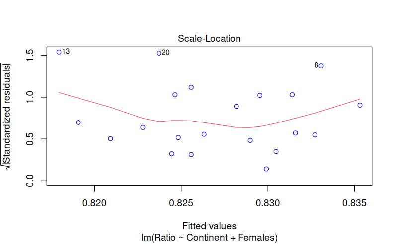

```r
plot(fit_add, which=3, col=c("blue"))
```

### Hypotéza

H0: Residua jsou homoskedastická.

HA: Residua nejsou homoskedastická (jsou heteroskedastická).

```r
ols_test_breusch_pagan(fit_add)
```

```
 Breusch Pagan Test for Heteroskedasticity
 -----------------------------------------
 Ho: the variance is constant
 Ha: the variance is not constant

              Data
 ---------------------------------
 Response : Ratio
 Variables: fitted values of Ratio

        Test Summary
 ----------------------------
 DF            =    1
 Chi2          =    1.057215
 Prob > Chi2   =    0.3038512
```